# Cyclistic Case Study

Augustinus Joseph

2023-08-26

# Cyclistic User Marketing Analysis: Identifying Differentiating Features

This case study, as per Moreno’s request representing Cyclistic via Google and Motivate International Inc, seeks to examine customer behavior and identify differentiating traits to figure out how to increase the number of annual memberships.

## Setting up my environment

### Downloading the Data

To perform the analysis, I had to access the data through this link provided by Google and Motivate International via Coursera.

find the dataset [here](https://divvy-tripdata.s3.amazonaws.com/index.html).

### Addressing Accessibility, Licensing, Privacy, and Security

The data has been made available by Motivate International Inc. under this license. This is public data. Data-Privacy protocols restrict the use of riders’ personally identifiable information. This means that you won’t be able to connect pass purchases to credit card numbers to determine if casual riders live in the Cyclistic service area or if they have purchased multiple single passes.

### Organizing and Preparing the Data

After inspecting the spreadsheets (checking for primary and foreign keys), I noticed a large number of observations. Since there were thirteen datasets to combine, I created a directory called “Accumulative Trip Data”; it consists of data gathered between April 2022 and April 2023. When trying this on your computer, make sure to have your folder sub-directory path set up correctly for the code to process.

If you follow along, your folder should look something like this:

[figure not shown]

DF Config Example Screenshot

### Load Packages

```r
library(tidyverse)
library(readxl)
library(skimr)
library(janitor)
```

```r
library(dplyr)
library(ggplot2)
library(lubridate)
library(shiny)
library(tinytex)
library(vitae)
library(stringr)
library(purrr)
```

### Load the Data

```r
datapak_cyclistic_df <-
  dir("Accumulative Trip Data/",
      full.names = T) %>%
  map_df(read_csv)
```

### Inspect the data

```r
head(datapak_cyclistic_df)
```

```
## # A tibble: 6 × 13
##   ride_id          rideable_type started_at          ended_at
##   <chr>            <chr>         <dttm>              <dttm>
## 1 3564070EEFD12711 electric_bike 2022-04-06 17:42:48 2022-04-06 17:54:36
## 2 0B820C7FCF22F489 classic_bike  2022-04-24 19:23:07 2022-04-24 19:43:17
## 3 89EEEE32293F07FF classic_bike  2022-04-20 19:29:08 2022-04-20 19:35:16
## 4 84D4751AEB31888D classic_bike  2022-04-22 21:14:06 2022-04-22 21:23:29
## 5 5664BCF0D1DE7A8B electric_bike 2022-04-16 15:56:30 2022-04-16 16:02:11
## 6 AA9EB7BD2E1FC128 classic_bike  2022-04-21 16:52:33 2022-04-21 16:56:51
## # ℹ 9 more variables: start_station_name <chr>, start_station_id <chr>,
## #   end_station_name <chr>, end_station_id <chr>, start_lat <dbl>,
## #   start_lng <dbl>, end_lat <dbl>, end_lng <dbl>, member_casual <chr>
```

```r
str(datapak_cyclistic_df)
```

```
## spc_tbl_ [6,230,310 × 13] (S3: spec_tbl_df/tbl_df/tbl/data.frame)
##  $ ride_id           : chr [1:6230310] "3564070EEFD12711" "0B820C7FCF22F489" "89EEEE32293F07FF" "84D4751AEB31888D" ...
##  $ rideable_type     : chr [1:6230310] "electric_bike" "classic_bike" "classic_bike" "classic_bike" ...
##  $ started_at        : POSIXct[1:6230310], format: "2022-04-06 17:42:48" "2022-04-24 19:23:07" ...
##  $ ended_at          : POSIXct[1:6230310], format: "2022-04-06 17:54:36" "2022-04-24 19:43:17" ...
##  $ start_station_name: chr [1:6230310] "Paulina St & Howard St" "Wentworth Ave & Cermak Rd" "Halsted St & Polk St" "Wentworth Ave & Cermak Rd" ...
##  $ start_station_id  : chr [1:6230310] "515" "13075" "TA1307000121" "13075" ...
##  $ end_station_name  : chr [1:6230310] "University Library (NU)" "Green St & Madison St" "Green St & Madison St" "Delano Ct & Roosevelt Rd" ...
##  $ end_station_id    : chr [1:6230310] "605" "TA1307000120" "TA1307000120" "KA1706005007" ...
##  $ start_lat         : num [1:6230310] 42 41.9 41.9 41.9 41.9 ...
##  $ start_lng         : num [1:6230310] -87.7 -87.6 -87.6 -87.6 -87.6 ...
##  $ end_lat           : num [1:6230310] 42.1 41.9 41.9 41.9 41.9 ...
##  $ end_lng           : num [1:6230310] -87.7 -87.6 -87.6 -87.6 -87.6 ...
##  $ member_casual     : chr [1:6230310] "member" "member" "member" "casual" ...
##  - attr(*, "spec")=
##   .. cols(
##   ..   ride_id = col_character(),
##   ..   rideable_type = col_character(),
##   ..   started_at = col_datetime(format = ""),
##   ..   ended_at = col_datetime(format = ""),
##   ..   start_station_name = col_character(),
##   ..   start_station_id = col_character(),
##   ..   end_station_name = col_character(),
##   ..   end_station_id = col_character(),
##   ..   start_lat = col_double(),
##   ..   start_lng = col_double(),
##   ..   end_lat = col_double(),
##   ..   end_lng = col_double(),
##   ..   member_casual = col_character()
##   .. )
##  - attr(*, "problems")=<externalptr>
```

```r
glimpse(datapak_cyclistic_df)
```

```
## Rows: 6,230,310
## Columns: 13
## $ ride_id            <chr> "3564070EEFD12711", "0B820C7FCF22F489", "89EEEE3229…
## $ rideable_type      <chr> "electric_bike", "classic_bike", "classic_bike", "c…
## $ started_at         <dttm> 2022-04-06 17:42:48, 2022-04-24 19:23:07, 2022-04-…
## $ ended_at           <dttm> 2022-04-06 17:54:36, 2022-04-24 19:43:17, 2022-04-…
## $ start_station_name <chr> "Paulina St & Howard St", "Wentworth Ave & Cermak R…
## $ start_station_id   <chr> "515", "13075", "TA1307000121", "13075", "TA1307000…
## $ end_station_name   <chr> "University Library (NU)", "Green St & Madison St",…
## $ end_station_id     <chr> "605", "TA1307000120", "TA1307000120", "KA170600500…
## $ start_lat          <dbl> 42.01913, 41.85308, 41.87184, 41.85308, 41.87181, 4…
## $ start_lng          <dbl> -87.67353, -87.63193, -87.64664, -87.63193, -87.646…
## $ end_lat            <dbl> 42.05294, 41.88189, 41.88189, 41.86749, 41.88224, 4…
## $ end_lng            <dbl> -87.67345, -87.64879, -87.64879, -87.63219, -87.641…
## $ member_casual      <chr> "member", "member", "member", "casual", "member", "…
```

```r
colnames(datapak_cyclistic_df)
```

```
##  [1] "ride_id"            "rideable_type"      "started_at"
##  [4] "ended_at"           "start_station_name" "start_station_id"
##  [7] "end_station_name"   "end_station_id"     "start_lat"
## [10] "start_lng"          "end_lat"            "end_lng"
## [13] "member_casual"
```

```r
skim_without_charts(datapak_cyclistic_df)
```

Data summary

| Name | datapak_cyclistic_df |
| --- | --- |
| Number of rows | 6230310 |
| Number of columns | 13 |
| _______________________ |  |
| Column type frequency: |  |
| character | 7 |
| numeric | 4 |
| POSIXct | 2 |
| ________________________ |  |
| Group variables | None |

**Variable type: character**

| skim_variable | n_missing | complete_rate | min | max | empty | n_unique | whitespace |
| --- | --- | --- | --- | --- | --- | --- | --- |
| ride_id | 0 | 1.00 | 16 | 16 | 0 | 6230310 | 0 |
| rideable_type | 0 | 1.00 | 11 | 13 | 0 | 3 | 0 |
| start_station_name | 902896 | 0.86 | 3 | 64 | 0 | 1722 | 0 |
| start_station_id | 903028 | 0.86 | 3 | 36 | 0 | 1320 | 0 |
| end_station_name | 964949 | 0.85 | 3 | 64 | 0 | 1742 | 0 |
| end_station_id | 965090 | 0.85 | 3 | 36 | 0 | 1324 | 0 |
| member_casual | 0 | 1.00 | 6 | 6 | 0 | 2 | 0 |

**Variable type: numeric**

| skim_variable | n_missing | complete_rate | mean | sd | p0 | p25 | p50 | p75 | p100 |
| --- | --- | --- | --- | --- | --- | --- | --- | --- | --- |
| start_lat | 0 | 1 | 41.90 | 0.05 | 41.64 | 41.88 | 41.90 | 41.93 | 42.07 |
| start_lng | 0 | 1 | -87.65 | 0.03 | -87.84 | -87.66 | -87.64 | -87.63 | -87.52 |
| end_lat | 6290 | 1 | 41.90 | 0.07 | 0.00 | 41.88 | 41.90 | 41.93 | 42.37 |
| end_lng | 6290 | 1 | -87.65 | 0.10 | -88.14 | -87.66 | -87.64 | -87.63 | 0.00 |

**Variable type: POSIXct**

| skim_variable | n_missing | complete_rate | min | max | median | n_unique |
| --- | --- | --- | --- | --- | --- | --- |
| started_at | 0 | 1 | 2022-04-01 00:01:48 | 2023-04-30 23:59:05 | 2022-08-21 12:55:50 | 5242951 |
| ended_at | 0 | 1 | 2022-04-01 00:02:15 | 2023-05-03 10:37:12 | 2022-08-21 13:20:40 | 5257508 |

```r
summary(datapak_cyclistic_df)
```

```
##    ride_id          rideable_type        started_at
##  Length:6230310     Length:6230310     Min.   :2022-04-01 00:01:48.00
##  Class :character   Class :character   1st Qu.:2022-06-22 23:26:45.50
##  Mode  :character   Mode  :character   Median :2022-08-21 12:55:50.50
##                                        Mean   :2022-09-10 07:29:08.01
##                                        3rd Qu.:2022-11-02 14:41:48.50
##                                        Max.   :2023-04-30 23:59:05.00
##
##     ended_at                      start_station_name start_station_id
##  Min.   :2022-04-01 00:02:15.00   Length:6230310     Length:6230310
##  1st Qu.:2022-06-22 23:56:19.00   Class :character   Class :character
##  Median :2022-08-21 13:20:40.50   Mode  :character   Mode  :character
##  Mean   :2022-09-10 07:47:59.50
##  3rd Qu.:2022-11-02 14:56:04.25
##  Max.   :2023-05-03 10:37:12.00
##
##  end_station_name   end_station_id       start_lat       start_lng
##  Length:6230310     Length:6230310     Min.   :41.64   Min.   :-87.84
##  Class :character   Class :character   1st Qu.:41.88   1st Qu.:-87.66
##  Mode  :character   Mode  :character   Median :41.90   Median :-87.64
##                                        Mean   :41.90   Mean   :-87.65
##                                        3rd Qu.:41.93   3rd Qu.:-87.63
##                                        Max.   :42.07   Max.   :-87.52
##
##     end_lat         end_lng       member_casual
##  Min.   : 0.00   Min.   :-88.14   Length:6230310
##  1st Qu.:41.88   1st Qu.:-87.66   Class :character
##  Median :41.90   Median :-87.64   Mode  :character
##  Mean   :41.90   Mean   :-87.65
##  3rd Qu.:41.93   3rd Qu.:-87.63
##  Max.   :42.37   Max.   :  0.00
##  NA's   :6290    NA's   :6290
```

## Data Integrity Acknowledgement

### Missing values

Analyzing the data, I have a few quick takeaways. Outside of the spreadsheet collectively consisting of more than 6 million unique observations composed of a combination of different data structure types, I also caught a bunch of missing values. These missing values differ between each row and further between the spreadsheets. I will only get rid of rows if it is necessary to perform calculations. Furthermore, this dataset is being used in a map chart; So, to keep everything consistent the dataset will primarily be maintained.

In this dataset, missing values consist of:

- missing numeric values for end lat and longitude.
- Missing end and start station names and IDs.

### Calculations

#### Missing Lat/Lon

```r
paste(6290/6230310*100 ,'%',sep = '')
```

```
## [1] "0.100958058266764%"
```

Missing end latitude and longitude percentage: .1009% of the data.

#### Missing Station Designations

##### Start Station Name

```r
print(sprintf("%.2f%%",902896/6230310*100))
```

```
## [1] "14.49%"
```

Missing start station name percentage: 14.49% of the data.

##### Start Station ID

```r
print(sprintf("%.2f%%",903028/6230310*100))
```

```
## [1] "14.49%"
```

Missing start station ID percentage: 14.49% of the data.

##### End Station Name

```r
print(sprintf("%.2f%%",964949/6230310*100))
```

```
## [1] "15.49%"
```

Missing end station names percentage: 15.49% of the data.

##### End Station ID

```r
print(sprintf("%.2f%%",965090/6230310*100))
```

```
## [1] "15.49%"
```

Missing end station ID percentage: 15.49% of the data.

##### Total Missing Station Name and ID Percentages

```r
print(sprintf("%.2f%%",(14.492 + 15.490 + 14.49411 + 15.48798)/4))
```

```
## [1] "14.99%"
```

Missing end and start station designations account for 14.99% of the data.

### Data Inconsistencies

The various kinds of “station_id” are labeled inconsistently.

Inconsistencies exist in these columns:

- “start_station_id”
- “end_station_id”

Across both ‘station_id’ columns, there is a complete absence of proper labeling consistency. Before this data is worked with, it should be noted that if the missing values are omitted, it could be advised to gather more data *if* any stakeholders believe the 15% of missing designations are a significant portion to account for. While this highlights a point where more data needs to be gathered, the missing data is not relevant to my analysis. Additionally, the missing values fall under the standard threshold, so even if rows were removed, the dataset is still *technically* workable. Moreover, the lack of consistent labeling is also irrelevant to this analysis and has no bearing on the findings. Again, if any of the data is significant to stakeholders it would be advised to gather more because, in some cases, all rows are affected.

## Transform And Organize The Data

I need to truncate and remove irrelevant data.

```r
trm_cyc_df <- datapak_cyclistic_df %>%
  select(ride_id, rideable_type, started_at, ended_at, start_station_name,
         end_station_name, member_casual)

head(trm_cyc_df)
```

```
## # A tibble: 6 × 7
##   ride_id          rideable_type started_at          ended_at
##   <chr>            <chr>         <dttm>              <dttm>
## 1 3564070EEFD12711 electric_bike 2022-04-06 17:42:48 2022-04-06 17:54:36
## 2 0B820C7FCF22F489 classic_bike  2022-04-24 19:23:07 2022-04-24 19:43:17
## 3 89EEEE32293F07FF classic_bike  2022-04-20 19:29:08 2022-04-20 19:35:16
## 4 84D4751AEB31888D classic_bike  2022-04-22 21:14:06 2022-04-22 21:23:29
## 5 5664BCF0D1DE7A8B electric_bike 2022-04-16 15:56:30 2022-04-16 16:02:11
## 6 AA9EB7BD2E1FC128 classic_bike  2022-04-21 16:52:33 2022-04-21 16:56:51
## # ℹ 3 more variables: start_station_name <chr>, end_station_name <chr>,
## #   member_casual <chr>
```

Upon reviewing the data, I believe renaming certain columns and labels would be beneficial. For instance, the “annual member” is currently listed as “member”. To maintain clear and consistent findings, it is best to rename it and minimize the potential for confusion. Additionally, I believe calculating ride duration can provide extra context when working to differentiate the member types.

```r
ctrm_cyc_df <- trm_cyc_df %>%
  select(ride_id, rideable_type, started_at, ended_at, start_station_name,
         end_station_name, member_casual) %>%
  rename(start_time = started_at, end_time = ended_at,
         member_type = member_casual) %>%
  mutate(
    member_type = ifelse(member_type == "member", "Annual", member_type),
    member_type = ifelse(member_type == "casual", "Casual", member_type),
    ride_duration = as.numeric(difftime(end_time, start_time, units = "secs"))
  ) %>%
  filter(ride_duration >= 0)

head(ctrm_cyc_df)
```

```
## # A tibble: 6 × 8
##   ride_id          rideable_type start_time          end_time
##   <chr>            <chr>         <dttm>              <dttm>
## 1 3564070EEFD12711 electric_bike 2022-04-06 17:42:48 2022-04-06 17:54:36
## 2 0B820C7FCF22F489 classic_bike  2022-04-24 19:23:07 2022-04-24 19:43:17
## 3 89EEEE32293F07FF classic_bike  2022-04-20 19:29:08 2022-04-20 19:35:16
## 4 84D4751AEB31888D classic_bike  2022-04-22 21:14:06 2022-04-22 21:23:29
## 5 5664BCF0D1DE7A8B electric_bike 2022-04-16 15:56:30 2022-04-16 16:02:11
## 6 AA9EB7BD2E1FC128 classic_bike  2022-04-21 16:52:33 2022-04-21 16:56:51
## # ℹ 4 more variables: start_station_name <chr>, end_station_name <chr>,
## #   member_type <chr>, ride_duration <dbl>
```

Cleaning the data, I have exposed 103 observations that have ride times of less than zero seconds. This is impossible, let’s see why!

```r
lzctrm_cyc_df <- trm_cyc_df %>%
  select(ride_id, rideable_type, started_at, ended_at, start_station_name,
         end_station_name, member_casual) %>%
  rename(start_time = started_at, end_time = ended_at,
         member_type = member_casual) %>%
  mutate(
    member_type = ifelse(member_type == "member", "Annual", member_type),
    member_type = ifelse(member_type == "casual", "Casual", member_type),
    ride_duration = as.numeric(difftime(end_time, start_time, units = "secs"))
  ) %>%
  filter(ride_duration < 0)

head(lzctrm_cyc_df)
```

```
## # A tibble: 6 × 8
##   ride_id          rideable_type start_time          end_time
##   <chr>            <chr>         <dttm>              <dttm>
## 1 0793C9208A64302A electric_bike 2022-05-30 11:06:29 2022-05-30 11:06:17
## 2 B897BE02B21FA75E electric_bike 2022-06-07 19:15:39 2022-06-07 17:05:37
## 3 072E947E156D142D electric_bike 2022-06-07 19:14:46 2022-06-07 17:07:45
## 4 6A871510E302E8CD electric_bike 2022-06-23 19:22:57 2022-06-23 19:21:46
## 5 BF114472ABA0289C electric_bike 2022-06-07 19:14:47 2022-06-07 17:05:42
## 6 B3BE8FE661F79405 electric_bike 2022-06-07 16:18:37 2022-06-07 16:07:28
## # ℹ 4 more variables: start_station_name <chr>, end_station_name <chr>,
## #   member_type <chr>, ride_duration <dbl>
```

It appears that the reason why there are a handful of rows with ride durations of less than zero is because those rows’ end times are marked to start before the start time. The time stamps suggest the dates were swapped or logged incorrectly. Now that we know what is causing the issue, we can go ahead and cut them out to start performing calculations and creating plots.

Now, I arrange the data:

```r
actrm_cyc_df<- arrange(ctrm_cyc_df, -ride_duration)

head(actrm_cyc_df)
```

```
## # A tibble: 6 × 8
##   ride_id          rideable_type start_time          end_time
##   <chr>            <chr>         <dttm>              <dttm>
## 1 7D4CB0DD5137CA9A docked_bike   2022-10-01 15:04:38 2022-10-30 08:51:53
## 2 DCFE0DB8022DFABC docked_bike   2022-05-08 00:28:53 2022-06-02 04:46:41
## 3 94DD1FB2367EA8B6 docked_bike   2022-06-15 07:56:59 2022-07-10 04:57:37
## 4 70835A30C542BA2E docked_bike   2022-07-09 01:02:46 2022-08-01 19:11:35
## 5 3BFD0599F253B024 docked_bike   2022-07-09 01:03:19 2022-08-01 19:11:26
## 6 A256444CE831A7EE docked_bike   2022-07-09 01:02:45 2022-08-01 18:51:57
## # ℹ 4 more variables: start_station_name <chr>, end_station_name <chr>,
## #   member_type <chr>, ride_duration <dbl>
```

```r
summary(actrm_cyc_df)
```

```
##    ride_id          rideable_type        start_time
##  Length:6230207     Length:6230207     Min.   :2022-04-01 00:01:48.00
##  Class :character   Class :character   1st Qu.:2022-06-22 23:24:33.00
##  Mode  :character   Mode  :character   Median :2022-08-21 12:55:25.00
##                                        Mean   :2022-09-10 07:28:50.85
##                                        3rd Qu.:2022-11-02 14:40:39.50
##                                        Max.   :2023-04-30 23:59:05.00
##     end_time                      start_station_name end_station_name
##  Min.   :2022-04-01 00:02:15.00   Length:6230207     Length:6230207
##  1st Qu.:2022-06-22 23:54:30.50   Class :character   Class :character
##  Median :2022-08-21 13:19:58.00   Mode  :character   Mode  :character
##  Mean   :2022-09-10 07:47:42.49
##  3rd Qu.:2022-11-02 14:55:19.50
##  Max.   :2023-05-03 10:37:12.00
##  member_type        ride_duration
##  Length:6230207     Min.   :      0
##  Class :character   1st Qu.:    338
##  Mode  :character   Median :    597
##                     Mean   :   1132
##                     3rd Qu.:   1073
##                     Max.   :2483235
```

## Data Summary Calculations

### Ride Duration Statistics

Here, I gather basic essential statistics from the ride duration calculations.

#### All Member Statistics

```r
cyc_summ_df <- actrm_cyc_df %>%
  summarize(
    max_ride_duration = max(ride_duration, na.rm = TRUE),
    min_ride_duration = min(ride_duration, na.rm = TRUE),
    average_ride_duration = mean(ride_duration, na.rm = TRUE),
    mode_ride_duration = as.numeric(names(sort(table(ride_duration), decreasing = TRUE))[1]),
        Q1 = quantile(ride_duration, 0.25, na.rm = TRUE),
    Q3 = quantile(ride_duration, 0.75, na.rm = TRUE),
    IQR = Q3 - Q1,
    Std_Dev = sd(ride_duration, na.rm = TRUE),
    Variance = var(ride_duration, na.rm = TRUE),
    Range = max_ride_duration - min_ride_duration
  )

print(cyc_summ_df)
```

```
## # A tibble: 1 × 10
##   max_ride_duration min_ride_duration average_ride_duration mode_ride_duration
##               <dbl>             <dbl>                 <dbl>              <dbl>
## 1           2483235                 0                 1132.                323
## # ℹ 6 more variables: Q1 <dbl>, Q3 <dbl>, IQR <dbl>, Std_Dev <dbl>,
## #   Variance <dbl>, Range <dbl>
```

Since the goal is to understand the difference between the two member types, let’s do a specialized summary for each group.

#### Annual Member Statistics

```r
anu_cyc_df <- actrm_cyc_df %>%
  select(ride_id, rideable_type, start_time, end_time, start_station_name,
         end_station_name, member_type, ride_duration) %>%
  filter(member_type == "Annual")

head(anu_cyc_df)
```

```
## # A tibble: 6 × 8
##   ride_id          rideable_type start_time          end_time
##   <chr>            <chr>         <dttm>              <dttm>
## 1 2EF6AEC782BD1F60 classic_bike  2023-03-11 11:53:46 2023-03-12 13:53:26
## 2 20E586AE9E008FD4 classic_bike  2023-03-11 15:33:08 2023-03-12 17:32:46
## 3 5B4EBEF83AA8E9DB classic_bike  2022-04-01 19:43:03 2022-04-02 20:43:01
## 4 DE27BAEC41348C76 classic_bike  2022-04-11 17:31:29 2022-04-12 18:31:26
## 5 1355603564DA306E classic_bike  2022-06-14 05:38:47 2022-06-15 06:38:44
## 6 7C362BD0738D4083 classic_bike  2022-06-15 09:46:43 2022-06-16 10:46:40
## # ℹ 4 more variables: start_station_name <chr>, end_station_name <chr>,
## #   member_type <chr>, ride_duration <dbl>
```

```r
skim_without_charts(anu_cyc_df)
```

Data summary

| Name | anu_cyc_df |
| --- | --- |
| Number of rows | 3745537 |
| Number of columns | 8 |
| _______________________ |  |
| Column type frequency: |  |
| character | 5 |
| numeric | 1 |
| POSIXct | 2 |
| ________________________ |  |
| Group variables | None |

**Variable type: character**

| skim_variable | n_missing | complete_rate | min | max | empty | n_unique | whitespace |
| --- | --- | --- | --- | --- | --- | --- | --- |
| ride_id | 0 | 1.00 | 16 | 16 | 0 | 3745537 | 0 |
| rideable_type | 0 | 1.00 | 12 | 13 | 0 | 2 | 0 |
| start_station_name | 533595 | 0.86 | 3 | 64 | 0 | 1541 | 0 |
| end_station_name | 530950 | 0.86 | 9 | 64 | 0 | 1532 | 0 |
| member_type | 0 | 1.00 | 6 | 6 | 0 | 1 | 0 |

**Variable type: numeric**

| skim_variable | n_missing | complete_rate | mean | sd | p0 | p25 | p50 | p75 | p100 |
| --- | --- | --- | --- | --- | --- | --- | --- | --- | --- |
| ride_duration | 0 | 1 | 746.07 | 1694.43 | 0 | 299 | 517 | 895 | 93580 |

**Variable type: POSIXct**

| skim_variable | n_missing | complete_rate | min | max | median | n_unique |
| --- | --- | --- | --- | --- | --- | --- |
| start_time | 0 | 1 | 2022-04-01 00:01:48 | 2023-04-30 23:57:35 | 2022-09-02 21:11:26 | 3391985 |
| end_time | 0 | 1 | 2022-04-01 00:07:07 | 2023-05-01 12:46:07 | 2022-09-02 21:26:04 | 3396917 |

```r
anu_summ_df <- anu_cyc_df %>%
  summarize(
    max_ride_duration = max(ride_duration, na.rm = TRUE),
    min_ride_duration = min(ride_duration, na.rm = TRUE),
    average_ride_duration = mean(ride_duration, na.rm = TRUE),
    mode_ride_duration = names(sort(table(ride_duration), decreasing = TRUE))[1],
        Q1 = quantile(ride_duration, 0.25, na.rm = TRUE),
    Q3 = quantile(ride_duration, 0.75, na.rm = TRUE),
    IQR = Q3 - Q1,
    Std_Dev = sd(ride_duration, na.rm = TRUE),
    Variance = var(ride_duration, na.rm = TRUE),
    Range = max_ride_duration - min_ride_duration
  )

print(anu_summ_df)
```

```
## # A tibble: 1 × 10
##   max_ride_duration min_ride_duration average_ride_duration mode_ride_duration
##               <dbl>             <dbl>                 <dbl> <chr>
## 1             93580                 0                  746. 274
## # ℹ 6 more variables: Q1 <dbl>, Q3 <dbl>, IQR <dbl>, Std_Dev <dbl>,
## #   Variance <dbl>, Range <dbl>
```

Okay, same process for the casual riders!

#### Casual Rider Statistics

```r
cas_cyc_df <- actrm_cyc_df %>%
  select(ride_id, rideable_type, start_time, end_time, start_station_name,
         end_station_name, member_type, ride_duration) %>%
  filter(member_type == "Casual")

head(cas_cyc_df)
```

```
## # A tibble: 6 × 8
##   ride_id          rideable_type start_time          end_time
##   <chr>            <chr>         <dttm>              <dttm>
## 1 7D4CB0DD5137CA9A docked_bike   2022-10-01 15:04:38 2022-10-30 08:51:53
## 2 DCFE0DB8022DFABC docked_bike   2022-05-08 00:28:53 2022-06-02 04:46:41
## 3 94DD1FB2367EA8B6 docked_bike   2022-06-15 07:56:59 2022-07-10 04:57:37
## 4 70835A30C542BA2E docked_bike   2022-07-09 01:02:46 2022-08-01 19:11:35
## 5 3BFD0599F253B024 docked_bike   2022-07-09 01:03:19 2022-08-01 19:11:26
## 6 A256444CE831A7EE docked_bike   2022-07-09 01:02:45 2022-08-01 18:51:57
## # ℹ 4 more variables: start_station_name <chr>, end_station_name <chr>,
## #   member_type <chr>, ride_duration <dbl>
```

```r
skim_without_charts(cas_cyc_df)
```

Data summary

| Name | cas_cyc_df |
| --- | --- |
| Number of rows | 2484670 |
| Number of columns | 8 |
| _______________________ |  |
| Column type frequency: |  |
| character | 5 |
| numeric | 1 |
| POSIXct | 2 |
| ________________________ |  |
| Group variables | None |

**Variable type: character**

| skim_variable | n_missing | complete_rate | min | max | empty | n_unique | whitespace |
| --- | --- | --- | --- | --- | --- | --- | --- |
| ride_id | 0 | 1.00 | 16 | 16 | 0 | 2484670 | 0 |
| rideable_type | 0 | 1.00 | 11 | 13 | 0 | 3 | 0 |
| start_station_name | 369276 | 0.85 | 3 | 64 | 0 | 1645 | 0 |
| end_station_name | 433983 | 0.83 | 3 | 64 | 0 | 1663 | 0 |
| member_type | 0 | 1.00 | 6 | 6 | 0 | 1 | 0 |

**Variable type: numeric**

| skim_variable | n_missing | complete_rate | mean | sd | p0 | p25 | p50 | p75 | p100 |
| --- | --- | --- | --- | --- | --- | --- | --- | --- | --- |
| ride_duration | 0 | 1 | 1712.85 | 16165.28 | 0 | 424 | 754 | 1406 | 2483235 |

**Variable type: POSIXct**

| skim_variable | n_missing | complete_rate | min | max | median | n_unique |
| --- | --- | --- | --- | --- | --- | --- |
| start_time | 0 | 1 | 2022-04-01 00:01:53 | 2023-04-30 23:59:05 | 2022-08-06 11:52:55 | 2266334 |
| end_time | 0 | 1 | 2022-04-01 00:02:15 | 2023-05-03 10:37:12 | 2022-08-06 12:21:08 | 2272758 |

```r
cas_summ_df <- cas_cyc_df %>%
  summarize(
    max_ride_duration = max(ride_duration, na.rm = TRUE),
    min_ride_duration = min(ride_duration, na.rm = TRUE),
    average_ride_duration = mean(ride_duration, na.rm = TRUE),
    mode_ride_duration = as.numeric(names(sort(table(ride_duration), decreasing = TRUE))[1]),
      Q1 = quantile(ride_duration, 0.25, na.rm = TRUE),
    Q3 = quantile(ride_duration, 0.75, na.rm = TRUE),
    IQR = Q3 - Q1,
    Std_Dev = sd(ride_duration, na.rm = TRUE),
    Variance = var(ride_duration, na.rm = TRUE),
    Range = max_ride_duration - min_ride_duration
  )

print(cas_summ_df)
```

```
## # A tibble: 1 × 10
##   max_ride_duration min_ride_duration average_ride_duration mode_ride_duration
##               <dbl>             <dbl>                 <dbl>              <dbl>
## 1           2483235                 0                 1713.                431
## # ℹ 6 more variables: Q1 <dbl>, Q3 <dbl>, IQR <dbl>, Std_Dev <dbl>,
## #   Variance <dbl>, Range <dbl>
```

These observations show us that casual riders have a longer average ride time and take longer rides than annual members.

### Total Rider Count

Now, do ride IDs symbolize total number of riders or simply total number of rides? Is there a way to find the total rider count? Upon observation, using functions like glimpse, it becomes apparent that there are 6,230,310 distinct ride IDs. Given that this count aligns with the total number of rows, it is advisable to inspect the ride IDs for any recurring elements.

Noting that rides with negative ride duration do not affect the outcome of this observation, they will be included to have the most accurate count of total rides.

```r
ttrm_cyc_df <- trm_cyc_df %>%
   select(ride_id, rideable_type, started_at, ended_at, start_station_name,
         end_station_name, member_casual) %>%
  rename(start_time = started_at, end_time = ended_at,
         member_type = member_casual) %>%
  mutate(
    member_type = ifelse(member_type == "member", "Annual", member_type),
    member_type = ifelse(member_type == "casual", "Casual", member_type),
    ride_duration = as.numeric(difftime(end_time, start_time, units = "secs"))
  )

View(ttrm_cyc_df)
```

#### All Ride IDs

Here, I find out how many unique ride IDs there are.

```r
ride_count <- ttrm_cyc_df %>%
  summarize(distinct_riders = n_distinct(ride_id))

print(ride_count)
```

```
## # A tibble: 1 × 1
##   distinct_riders
##             <int>
## 1         6230310
```

Here, I filter certain characters in a random ride ID to check for repeating elements.

```r
View(datapak_cyclistic_df[grepl("^AA", datapak_cyclistic_df$ride_id), ])
View(datapak_cyclistic_df[grepl("^AA98", datapak_cyclistic_df$ride_id), ])
View(datapak_cyclistic_df[grepl("^AA98C", datapak_cyclistic_df$ride_id), ])

print(datapak_cyclistic_df[grepl("^AA98C", datapak_cyclistic_df$ride_id), ])
```

```
## # A tibble: 9 × 13
##   ride_id          rideable_type started_at          ended_at
##   <chr>            <chr>         <dttm>              <dttm>
## 1 AA98C37E2AF90A11 docked_bike   2022-04-11 14:45:03 2022-04-11 14:58:22
## 2 AA98C5B961BBE113 electric_bike 2022-05-28 18:04:32 2022-05-28 18:08:36
## 3 AA98C370E99CFCE0 classic_bike  2022-06-01 17:48:16 2022-06-01 17:56:36
## 4 AA98C4A81BDC4C96 electric_bike 2022-06-10 13:13:49 2022-06-10 13:31:59
## 5 AA98C375D2890D06 classic_bike  2022-07-24 15:29:34 2022-07-24 15:50:48
## 6 AA98CF60DB9D7760 classic_bike  2022-09-21 18:44:07 2022-09-21 19:05:35
## 7 AA98C5FAEC17832D classic_bike  2023-01-31 23:19:11 2023-02-01 00:28:12
## 8 AA98C7AFBF0B9949 classic_bike  2023-01-08 22:02:12 2023-01-08 22:06:00
## 9 AA98CBF52BA3E6C3 electric_bike 2023-03-20 05:53:42 2023-03-20 06:00:16
## # ℹ 9 more variables: start_station_name <chr>, start_station_id <chr>,
## #   end_station_name <chr>, end_station_id <chr>, start_lat <dbl>,
## #   start_lng <dbl>, end_lat <dbl>, end_lng <dbl>, member_casual <chr>
```

After viewing this count, I conclude that the number of unique “ride_id”s is equal to the number of rows in the dataframe and there are no repeating IDs. Yet, upon scrutinizing the “ride_id”s, it becomes apparent that there are shared character sequences among the IDs, and it should be mentioned that some even share the same street names in their metadata. Due to the ambiguity in the “ride_id” sequencing method, these IDs do not provide an accurate representation of the overall count of subscribed members; they solely signify completed trips.

#### Annual Member Initiated Rides

let’s see how many rides were initiated by annual members.

```r
anu_count <- ttrm_cyc_df  %>%
   filter(member_type == "Annual") %>%
  summarize(distinct_rides = n_distinct(ride_id))

print(anu_count)
```

```
## # A tibble: 1 × 1
##   distinct_rides
##            <int>
## 1        3745586
```

#### Casual Rider Initiated Rides

let’s see how many rides were initiated by casual riders.

```r
cas_count <- cas_cyc_df %>%
  filter(member_type == "Casual") %>%
  summarize(distinct_rides = n_distinct(ride_id))

print(cas_count)
```

```
## # A tibble: 1 × 1
##   distinct_rides
##            <int>
## 1        2484670
```

### Member-Type Ride Percentages

Let’s see what percentage of rides are of each member type.

#### Annual Rides

```r
anu_percentage <- (sprintf("%.2f%%", (anu_count / ride_count) * 100))
print(anu_percentage)
```

```
## [1] "60.12%"
```

#### Casual Rides

```r
cas_percentage <- (sprintf("%.2f%%", (cas_count / ride_count) * 100))
print(cas_percentage)
```

```
## [1] "39.88%"
```

Key takeaways: There are 6,230,310 unique rides. Annual members make up 60.12% of total rides, whereas casual riders fill the remaining 39.88%.

### A Year In Reflection

Last but not least, let’s figure out how much ridership has increased for Cyclistic this season. To do that, we’ll compare the data between rides from April 2022 and 2023.

```r
april_2022 <- ctrm_cyc_df %>%
filter(format(start_time, "%Y-%m") == "2022-04")
april_2023 <- ctrm_cyc_df %>%
filter(format(start_time, "%Y-%m") == "2023-04")

head(april_2022)
```

```
## # A tibble: 6 × 8
##   ride_id          rideable_type start_time          end_time
##   <chr>            <chr>         <dttm>              <dttm>
## 1 3564070EEFD12711 electric_bike 2022-04-06 17:42:48 2022-04-06 17:54:36
## 2 0B820C7FCF22F489 classic_bike  2022-04-24 19:23:07 2022-04-24 19:43:17
## 3 89EEEE32293F07FF classic_bike  2022-04-20 19:29:08 2022-04-20 19:35:16
## 4 84D4751AEB31888D classic_bike  2022-04-22 21:14:06 2022-04-22 21:23:29
## 5 5664BCF0D1DE7A8B electric_bike 2022-04-16 15:56:30 2022-04-16 16:02:11
## 6 AA9EB7BD2E1FC128 classic_bike  2022-04-21 16:52:33 2022-04-21 16:56:51
## # ℹ 4 more variables: start_station_name <chr>, end_station_name <chr>,
## #   member_type <chr>, ride_duration <dbl>
```

```r
summary(april_2022)
```

```
##    ride_id          rideable_type        start_time
##  Length:371249      Length:371249      Min.   :2022-04-01 00:01:48.00
##  Class :character   Class :character   1st Qu.:2022-04-10 12:44:18.00
##  Mode  :character   Mode  :character   Median :2022-04-17 18:58:38.00
##                                        Mean   :2022-04-17 05:02:35.16
##                                        3rd Qu.:2022-04-23 20:44:14.00
##                                        Max.   :2022-04-30 23:59:54.00
##     end_time                      start_station_name end_station_name
##  Min.   :2022-04-01 00:02:15.00   Length:371249      Length:371249
##  1st Qu.:2022-04-10 13:05:50.00   Class :character   Class :character
##  Median :2022-04-17 19:18:53.00   Mode  :character   Mode  :character
##  Mean   :2022-04-17 05:20:13.27
##  3rd Qu.:2022-04-23 21:12:25.00
##  Max.   :2022-05-02 00:35:01.00
##  member_type        ride_duration
##  Length:371249      Min.   :      0
##  Class :character   1st Qu.:    317
##  Mode  :character   Median :    567
##                     Mean   :   1058
##                     3rd Qu.:   1047
##                     Max.   :1267332
```

```r
april_2022_summary <- april_2022 %>%
  summarize(
    max_ride_duration = max(ride_duration),
    min_ride_duration = min(ride_duration),
    avg_ride_duration = mean(ride_duration),
    mode_ride_duration = as.numeric(names(sort(table(ride_duration), decreasing = TRUE))[1]),
     Q1 = quantile(ride_duration, 0.25, na.rm = TRUE),
    Q3 = quantile(ride_duration, 0.75, na.rm = TRUE),
    IQR = Q3 - Q1,
    Std_Dev = sd(ride_duration, na.rm = TRUE),
    Variance = var(ride_duration, na.rm = TRUE),
   Range = max_ride_duration - min_ride_duration,
    ride_count = n()
  )

print(april_2022_summary)
```

```
## # A tibble: 1 × 11
##   max_ride_duration min_ride_duration avg_ride_duration mode_ride_duration    Q1
##               <dbl>             <dbl>             <dbl>              <dbl> <dbl>
## 1           1267332                 0             1058.                  2   317
## # ℹ 6 more variables: Q3 <dbl>, IQR <dbl>, Std_Dev <dbl>, Variance <dbl>,
## #   Range <dbl>, ride_count <int>
```

```r
head(april_2023)
```

```
## # A tibble: 6 × 8
##   ride_id          rideable_type start_time          end_time
##   <chr>            <chr>         <dttm>              <dttm>
## 1 8FE8F7D9C10E88C7 electric_bike 2023-04-02 08:37:28 2023-04-02 08:41:37
## 2 34E4ED3ADF1D821B electric_bike 2023-04-19 11:29:02 2023-04-19 11:52:12
## 3 5296BF07A2F77CB5 electric_bike 2023-04-19 08:41:22 2023-04-19 08:43:22
## 4 40759916B76D5D52 electric_bike 2023-04-19 13:31:30 2023-04-19 13:35:09
## 5 77A96F460101AC63 electric_bike 2023-04-19 12:05:36 2023-04-19 12:10:26
## 6 8D6A2328E19DC168 electric_bike 2023-04-19 12:17:34 2023-04-19 12:21:38
## # ℹ 4 more variables: start_station_name <chr>, end_station_name <chr>,
## #   member_type <chr>, ride_duration <dbl>
```

```r
summary(april_2023)
```

```
##    ride_id          rideable_type        start_time
##  Length:426586      Length:426586      Min.   :2023-04-01 00:00:02.00
##  Class :character   Class :character   1st Qu.:2023-04-10 13:22:16.25
##  Mode  :character   Mode  :character   Median :2023-04-15 09:52:13.00
##                                        Mean   :2023-04-16 05:15:36.85
##                                        3rd Qu.:2023-04-22 10:20:15.50
##                                        Max.   :2023-04-30 23:59:05.00
##     end_time                      start_station_name end_station_name
##  Min.   :2023-04-01 00:03:10.00   Length:426586      Length:426586
##  1st Qu.:2023-04-10 13:39:39.00   Class :character   Class :character
##  Median :2023-04-15 10:11:11.00   Mode  :character   Mode  :character
##  Mean   :2023-04-16 05:32:49.50
##  3rd Qu.:2023-04-22 10:35:57.50
##  Max.   :2023-05-03 10:37:12.00
##  member_type        ride_duration
##  Length:426586      Min.   :      0
##  Class :character   1st Qu.:    301
##  Mode  :character   Median :    535
##                     Mean   :   1033
##                     3rd Qu.:    970
##                     Max.   :1103729
```

```r
april_2023_summary <- april_2023 %>%
  summarize(
    max_ride_duration = max(ride_duration),
    min_ride_duration = min(ride_duration),
    avg_ride_duration = mean(ride_duration),
    mode_ride_duration = as.numeric(names(sort(table(ride_duration), decreasing = TRUE))[1]),
     Q1 = quantile(ride_duration, 0.25, na.rm = TRUE),
    Q3 = quantile(ride_duration, 0.75, na.rm = TRUE),
    IQR = Q3 - Q1,
    Std_Dev = sd(ride_duration, na.rm = TRUE),
    Variance = var(ride_duration, na.rm = TRUE),
    Range = max_ride_duration - min_ride_duration,
    ride_count = n()
  )
print(april_2023_summary)
```

```
## # A tibble: 1 × 11
##   max_ride_duration min_ride_duration avg_ride_duration mode_ride_duration    Q1
##               <dbl>             <dbl>             <dbl>              <dbl> <dbl>
## 1           1103729                 0             1033.                  4   301
## # ℹ 6 more variables: Q3 <dbl>, IQR <dbl>, Std_Dev <dbl>, Variance <dbl>,
## #   Range <dbl>, ride_count <int>
```

With these observations, we can see that the ride count increased by over 50,000 rides from April 2022 to April 2023. Additionally, with the summaries, we can see that the average ride duration was longer in 2022. In the same breath, 2022 had a longer max ride duration. Although the ride duration stats from 2022 outperform those of 2023, April 2023 was a more successful year as far as ride count goes. If ride costs are calculated by distance, maybe 2022 could have arguably been a better year. With all of this mentioned, if the goal is to figure out how to market to casual riders, there are more casual riders to work with this year.

## Data Visualizations

Now that we have cleaned, transformed, and inspected the data, let’s see what differences present themselves through visual inspection.

### Ride Duration Chart

##### Which members take the longest trips?

**Focus:** Examine ride duration and ride count to understand demographics and expose differentiating qualities between the member types.

#### Chart I

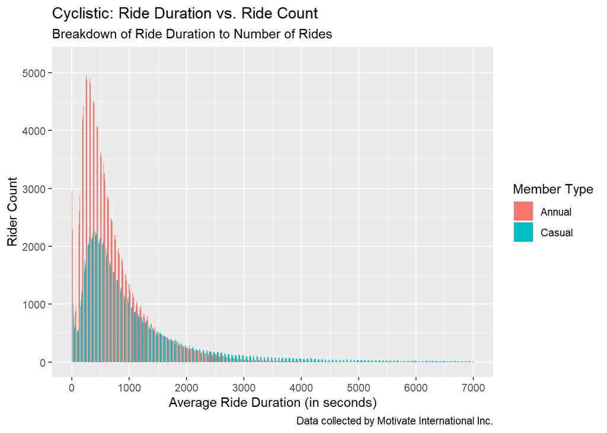

###### Missing Values

Due to the scale being used in the plot, most of the anomaly rides are not represented.

```r
print(sprintf("%.2f%%", 49748/6230310*100 ))
```

```
## [1] "0.80%"
```

In creating this plot, 49,747 rows were removed. However. this only accounts for 0.80% of the data so the plot is still 99.202% accurate. In this chart, annual members are represented in red and casual riders are in blue. Viewing this chart we can see that annual members outnumber casual riders for all trips between 0 and 1500 seconds. The data shows that annual members outnumber casual riders for all trips between 0 and 1500 seconds while casual riders generally outnumber annual members for all trips beyond that point. Additionally, the majority of annual member trips are around 270 seconds (roughly 4.5 minutes) and casual riders typically travel for around 430 seconds (roughly 7 minutes). It is important to note that, although casual riders tend to take drastically longer trips than annual members, the number of casual rides is not substantial enough to outweigh the annual member ride count. That being the case, it is equally as important to mention that there are a pretty consistent number of rides that support this trend of *long-distance casual rides*.

###### Marketing Notes:

With this information, you can pinpoint which users participated in the longest rides and offer special annual member promotions. For example, How about 35% off annual membership for casual riders who participate in trips with the longest ride duration?

### Time of Day

##### When are the peak activity hours for cyclistic members?

**Focus:** Analyze date and time of use patterns to further differentiate member types.

**DF Mod**

To perform my analysis, I have to extract chronologic metadata and make a few modifications to the original dataframe code.

```r
time_cyc_df <- ctrm_cyc_df %>%
  mutate(
    year = year(start_time),
    hour = hour(start_time),
    wday = wday(start_time),
    month = month(start_time)
  ) %>%
  group_by(year, month, hour, wday, member_type) %>%
  summarize(
    avg_ride_duration = mean(ride_duration),
    count = n()
  )
head(time_cyc_df)
```

```
## # A tibble: 6 × 7
## # Groups:   year, month, hour, wday [3]
##    year month  hour  wday member_type avg_ride_duration count
##   <dbl> <dbl> <int> <dbl> <chr>                   <dbl> <int>
## 1  2022     4     0     1 Annual                   678.   628
## 2  2022     4     0     1 Casual                  4989.   781
## 3  2022     4     0     2 Annual                   971.   144
## 4  2022     4     0     2 Casual                  7098.   127
## 5  2022     4     0     3 Annual                   667.   172
## 6  2022     4     0     3 Casual                   866.   125
```

#### Chart II

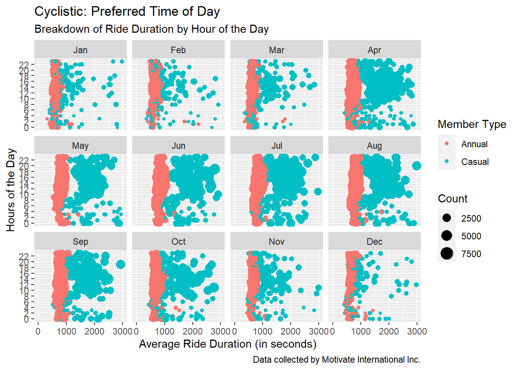

###### Missing Values

```r
paste(125/6230310*100,'%',sep = '')
```

```
## [1] "0.00200632071277352%"
```

###### Marketing Notes:

Since some of the casual riders seem to be seasonal, a season pass could be created. Maybe a promotion targeted towards users who ride through the winter months.

##### Cinder-Riders

Noticing the anomaly of the twilight hours, I had to see what useful observations could be extracted from the data. So, I sought to find differentiating qualities between the rider types.

###### Code Modification and Calculation

```r
rides_annual_member_0_to_4 <- time_cyc_df %>%
  filter(hour >= 0 & hour <= 4, member_type == "Annual")

rs_am_0t4 <- rides_annual_member_0_to_4 %>%
  summarize(
    count = sum(count),
    mean_duration = mean(avg_ride_duration),
    max_duration = max(avg_ride_duration),
    min_duration = min(avg_ride_duration),
    mode_duration = as.numeric(names(table(avg_ride_duration))[which.max(table(avg_ride_duration))])
  )
print(rs_am_0t4)
```

```
## # A tibble: 455 × 9
## # Groups:   year, month, hour [65]
##     year month  hour  wday count mean_duration max_duration min_duration
##    <dbl> <dbl> <int> <dbl> <int>         <dbl>        <dbl>        <dbl>
##  1  2022     4     0     1   628          678.         678.         678.
##  2  2022     4     0     2   144          971.         971.         971.
##  3  2022     4     0     3   172          667.         667.         667.
##  4  2022     4     0     4   178          581.         581.         581.
##  5  2022     4     0     5   148          569.         569.         569.
##  6  2022     4     0     6   314          699.         699.         699.
##  7  2022     4     0     7   571          694.         694.         694.
##  8  2022     4     1     1   418          695.         695.         695.
##  9  2022     4     1     2    91          601.         601.         601.
## 10  2022     4     1     3    95         1130.        1130.        1130.
## # ℹ 445 more rows
## # ℹ 1 more variable: mode_duration <dbl>
```

```r
View(rs_am_0t4)

count_an_0to4 <- sum(rides_annual_member_0_to_4$count)

print(count_an_0to4)
```

```
## [1] 96680
```

Now that we’ve quantified the behavior of annual members during the twilight hours, let’s see how they stack up against each other.

Same process:

```r
rides_casual_member_0_to_4 <- time_cyc_df %>%
  filter(hour >= 0 & hour <= 4, member_type == "Casual")

rs_cm_0t4 <- rides_casual_member_0_to_4 %>%
  summarize(
    count = sum(count),
    mean_duration = mean(avg_ride_duration),
    max_duration = max(avg_ride_duration),
    min_duration = min(avg_ride_duration),
    mode_duration = as.numeric(names(table(avg_ride_duration))[which.max(table(avg_ride_duration))])
  )
print(rs_cm_0t4)
```

```
## # A tibble: 455 × 9
## # Groups:   year, month, hour [65]
##     year month  hour  wday count mean_duration max_duration min_duration
##    <dbl> <dbl> <int> <dbl> <int>         <dbl>        <dbl>        <dbl>
##  1  2022     4     0     1   781         4989.        4989.        4989.
##  2  2022     4     0     2   127         7098.        7098.        7098.
##  3  2022     4     0     3   125          866.         866.         866.
##  4  2022     4     0     4   154          964.         964.         964.
##  5  2022     4     0     5   101         5298.        5298.        5298.
##  6  2022     4     0     6   249         1347.        1347.        1347.
##  7  2022     4     0     7   545         1358.        1358.        1358.
##  8  2022     4     1     1   526         2555.        2555.        2555.
##  9  2022     4     1     2    80        10439.       10439.       10439.
## 10  2022     4     1     3    66         1109.        1109.        1109.
## # ℹ 445 more rows
## # ℹ 1 more variable: mode_duration <dbl>
```

```r
View(rs_cm_0t4)

count_ca_0to4 <- sum(rides_casual_member_0_to_4$count)

print(count_ca_0to4)
```

```
## [1] 120339
```

Wow! Alright, the data shows us that casual riders are the royalty of the twilight hours not only in ride duration but in ride count!

### Day of Week

##### Which day of the week experiences the greatest influx of bike rides?

**Focus:** Discover what day of the week members prefer and if those stats change over the year to help further differentiate the member types.

#### Chart III

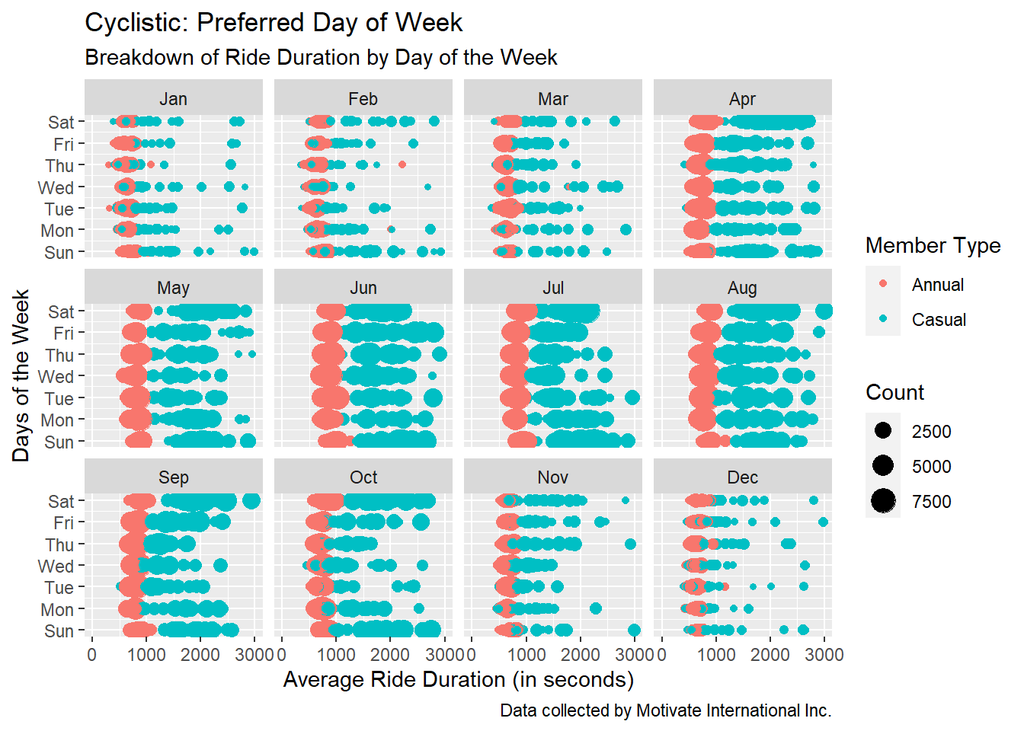

###### Missing Values

Due to the scale being used in the plot, most of the anomaly rides are not represented.

```r
paste(125/6230310*100,'%',sep = '')
```

```
## [1] "0.00200632071277352%"
```

In creating this graph, 125 rows were removed. However, these rides only account for 0.002% of rides. This visualization best represents the patterns of both member types during the week.

### Time of Year

##### Which months witness the highest volume of rides?

**Focus:** Analyze member behavior in reference to the months of the year to further differentiate the member types.

**DF Mod**

In this dataframe modification, ride counts for each month are organized by member type.

```r
m_df <- ttrm_cyc_df %>%
  select(ride_id, rideable_type, start_time, end_time, start_station_name,
         end_station_name, member_type) %>%
  mutate(start_month = month(start_time))


m_summary <- m_df %>%
  group_by(start_month, member_type) %>%
  summarize(rider_count = n())
head(arrange(m_summary, -rider_count))
```

```
## # A tibble: 6 × 3
## # Groups:   start_month [5]
##   start_month member_type rider_count
##         <dbl> <chr>             <int>
## 1           4 Annual           524137
## 2           8 Annual           427008
## 3           7 Annual           417433
## 4           7 Casual           406055
## 5           9 Annual           404642
## 6           6 Annual           400153
```

#### Chart IV

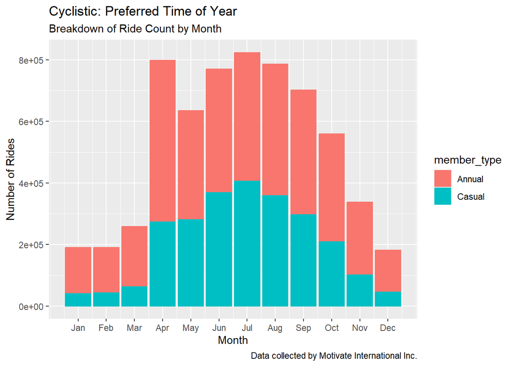

This chart is designed to highlight which times of the year are most attractive for Cyclistic users; showcasing the population of each member group and how they fluctuate over the course of a year. Annual members are represented in red and casual riders are in blue. One clear observation is that the most popular month for annual members is April with a count flowing over the figure of 500,000 rides. In the same breath, the most popular month for casual riders is July with a ride count of slightly over 400,000. Additionally, July is the most active month for Cyclistic users in total. Notably, this plot showcases how annual members lead in participation. For example, in contrast, the previously presented plots may have appeared to communicate the opposite message based on the way casual riders typically perform.

###### Marketing Notes:

Knowing July is the most active month for all users, a special summer promotion could be implemented to boost the number of annual members; Extended trial period: Provide casual users with an extended trial period for the annual membership during the summer. Gamification: create a game that awards casual riders if they ride for a minimum of X days, they get a free Annual membership for July. Creating a promotion for July will create more chances for the member types to engage and potentially initiate conversions through referral/word-of-mouth since this is the month when most users are active.

### Bike Type

##### What is the preferred bike type?

**PURPOSE:** Understanding what kinds of bikes each member type prefers will help us further differentiate the rider groups.

**DF Mod**

To perform calculations, I must create a summary for “member_type” related to “rideable_type”. Doing this will give us a clear count of what kind of member uses what kind of bike.

```r
b_summary <- m_df %>%
  group_by (member_type, rideable_type) %>%
  summarize(count = n())
arrange(b_summary, -count)
```

```
## # A tibble: 5 × 3
## # Groups:   member_type [2]
##   member_type rideable_type   count
##   <chr>       <chr>           <int>
## 1 Annual      electric_bike 1875078
## 2 Annual      classic_bike  1870508
## 3 Casual      electric_bike 1363301
## 4 Casual      classic_bike   938789
## 5 Casual      docked_bike    182634
```

```r
head(arrange(b_summary, -count))
```

```
## # A tibble: 5 × 3
## # Groups:   member_type [2]
##   member_type rideable_type   count
##   <chr>       <chr>           <int>
## 1 Annual      electric_bike 1875078
## 2 Annual      classic_bike  1870508
## 3 Casual      electric_bike 1363301
## 4 Casual      classic_bike   938789
## 5 Casual      docked_bike    182634
```

##### Calculations

Electric Bike vs. Classic Bike

I’ll use these calculations to provide context to the visualization.

###### Annual Member Bike Preference

```r
1875078 - 1870508
```

```
## [1] 4570
```

Annual Members Prefer Electric Bikes

###### Casual Members’ Bike Preference

```r
1363301 - 938789
```

```
## [1] 424512
```

Casual Members prefer electric bikes

###### Docked Bike Statistics

```r
182634
```

```
## [1] 182634
```

##### Bike Preference Ratio

I seek to establish the correlation between ride count demographics and bike type preferences. There are 2,484,670 casual riders and 3,745,537 annual members. Above are the calculations for each member type describing which bike types are preferred.

##### Casual Rider-to-Bike Ratio

###### Electric Bike Ratio

1363301/2484670 = u/100 u = 54.8099

5.5/10 casual riders prefer electric bikes.

###### Classic Bike Ratio

938789/2484670 = x/100 x = 37.7515

3.8/10 casual riders prefer classic bikes.

###### Docked Bike Ratio

182634/2484670 = x/100 x = 7.3458

##### Annual Member-to-Bike Ratio

###### Electric Bike Ratio

5/10 annual members prefer electric bikes.

###### Annual Member Classic Bike Ratio

1870508/3745586 = q/100 q = 49.9402

5/10 annual members prefer classic bikes.

#### Chart V

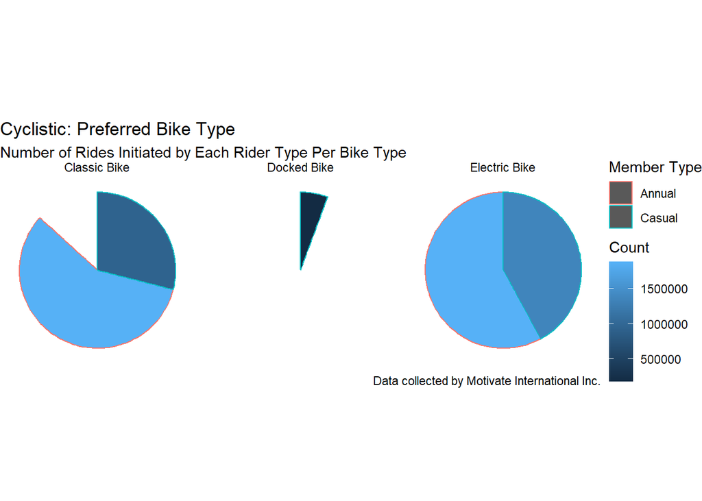

Since we know that annual members technically outnumber casual riders, it is no question, *who uses each bike type more*. However, we can still quantify the preferences of each member type. The chart above illustrates what kind of bikes each rider type prefers. Annual members are represented by portions outlined in red and casual riders are outlined in blue. With a slim (0.24%) difference of 4,570 rides (concerning the overall figure ), Annual members prefer electric bikes. On the other hand, casual riders prefer electric bikes by a difference of 424,512. After calculating the ratio of member type to bike type, I discovered that a little more than half of each population prefers electric bikes. The casual rider population prefers electric bikes more at 5.4/10 members. The Annual member population uses electric bikes at a rate of 5/10 members. For classic bikes, numbers are 4.9/10 for annual members and 3.8/10 for casual riders. Through this observation, we can safely conclude that there is an evident distinction between member types and bike preferences. Where casual riders’ opinions are stronger toward electric bikes, annual members are more neutral toward what kind of bikes they use. Moreover, it is worth mentioning that casual riders are the only member type that prefers the “Docked Bike” at .73/10 members.

###### Marketing Notes:

Noting that a small number of casual riders prefer classic bikes, providing a free trial with marketing that emphasizes fitness and health can be done to boost preference levels toward classic bikes and annual membership numbers. Or, give special promotions to members who use electric bikes.